# WGCNA分析原理和应用

Todzhu

2019年3月21日

# 1. 背景

### 1.1 基本概念

WGCNA（weighted gene co-expression network analysis，权重基因共表达网络分析）是一种分析多个样本基因表达模式的分析方法，可将表达模式相似的基因进行聚类(get modules)，并分析模块与特定性状或表型之间的关联关系，因此在基因组研究中被广泛应用

### 1.2 基本步骤

WGCNA分为表达量聚类分析和表型关联两部分，具体步骤包括基因之间相关系数的计算，共表达网络的构建，筛选特定模块，模块与性状关联，核心基因的筛选。

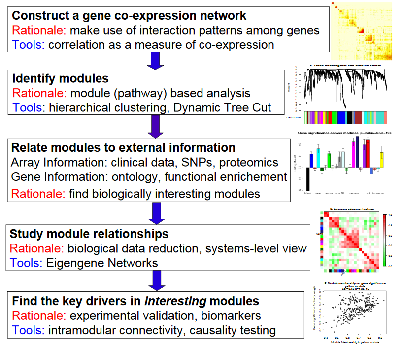

### 1.3 WGCNA相关术语

Co-expression weighted network

Module: 一组具有类似表达谱的基因，如果某些基因在一个生理过程或不同组织中总是具有相类似的表达变化，那么我们有理由认为这些基因在功能上是相关的，可以把他们定义为一个模块(module)。

Connectivity

Hub gene

# 2. 与网络相关的一些基础概念

### 2.1 无尺度网络(Scale free network)

基因网络符合无尺度分布

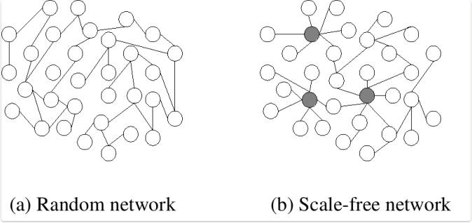

数学上的描述：假设m为某节点的连接数，统计所有节点的m值，n为节点连接数是m的节点的数量，m与n成反比。

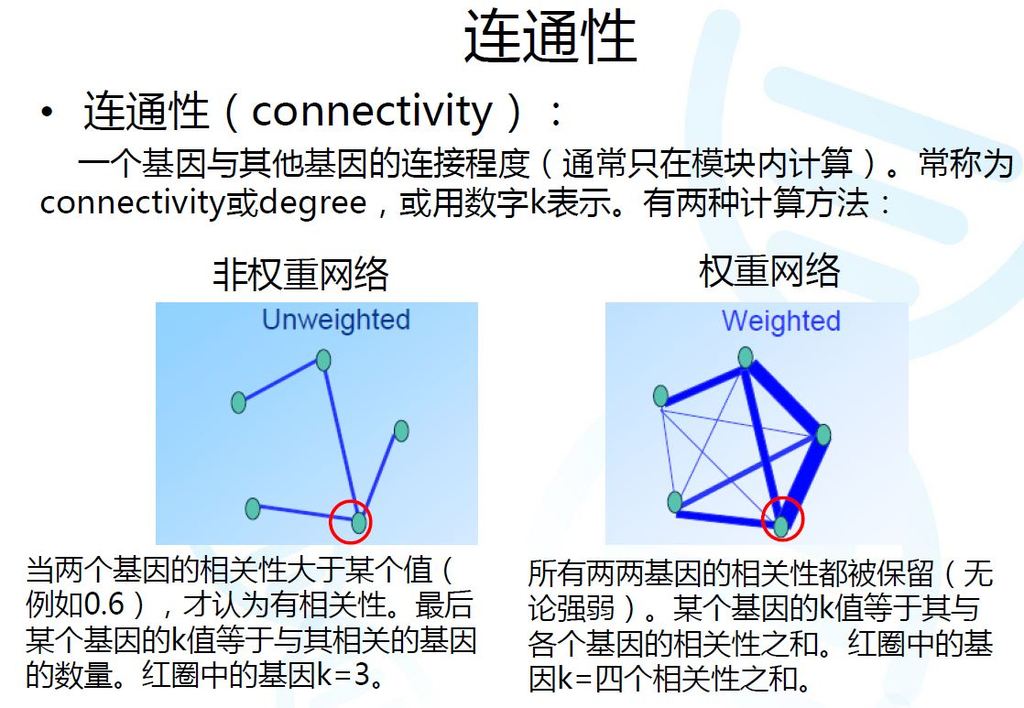

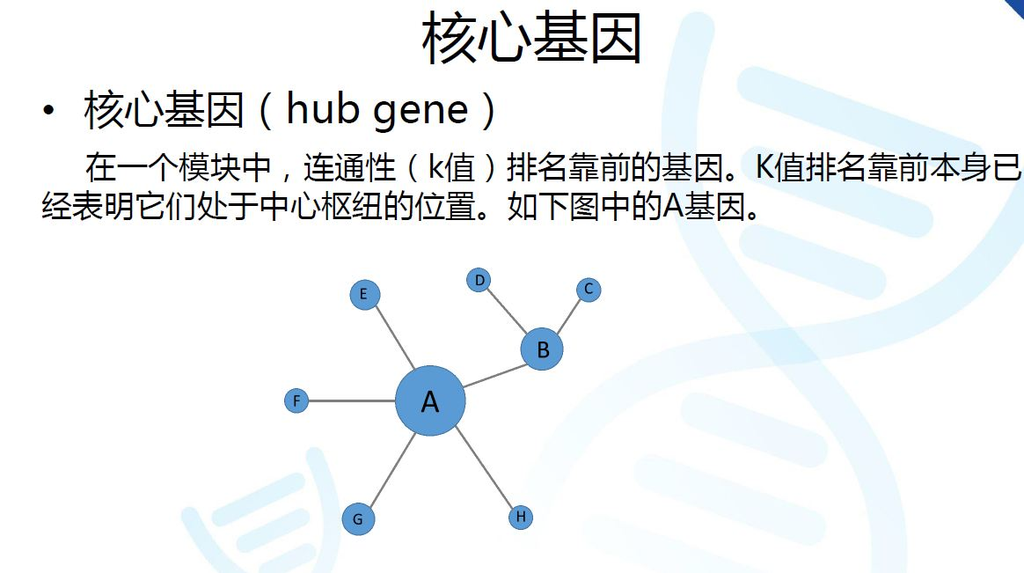

# 3. WGCNA网络构建过程

### Step1: 定义相似度矩阵

在构建邻接矩阵之前，首先需要根据基因表达谱定义一个相似表达矩阵，用 Sij 来表示一对基因的表达相似度，通过皮尔森相关系数来计算，得到一个相似度矩阵 S=[sij]

sij =|cor(i,j)|

### Step2: 将相似度矩阵转为邻接矩阵

为了将相似矩阵转为邻接矩阵来表示两个结点之间的连通强度，我们需要定义一个函数。

可以使用硬阈值的方法，如

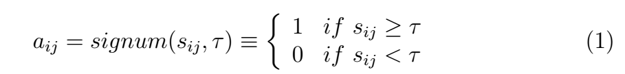

即如果i 和 j 是连通的，aij = 1，若 aij = 0 ，则表示这两个结点不连通

使用硬阈值的缺点：可能会漏掉一些信息，比如当阈值τ定为0.85时，当两个结点之间的相关系数为0.84时，尽管其相关性很高，但是连通强度依然为0。

为了避免这个缺点，引入两种软阈值的方法：

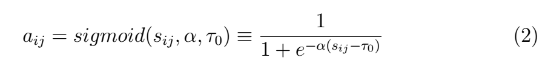

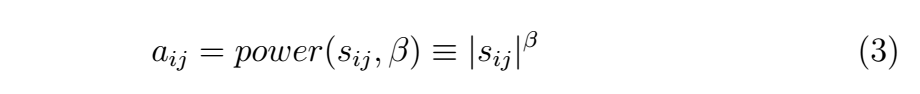

### Step3: TOM衡量基因相关性

如果直接拿Adjacency Matrix中的基因相关性指标进行module识别则未免有些过于简单了，为了保证芯片信息的充分利用，文章的作者提出了计算另一矩阵——topological overlap matrix(TOM)来衡量两个基因的相关性。建立这一矩阵的思想在于，任何两个基因的相关性不仅仅由他们的表达相似性直接决定，它还将A基因通过B基因与C基因的作用相关性纳入AC基因的TOM矩阵值中，以更精确地描述基因表达谱的类似性。

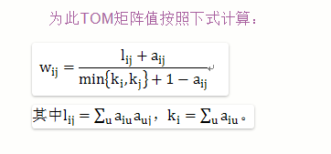

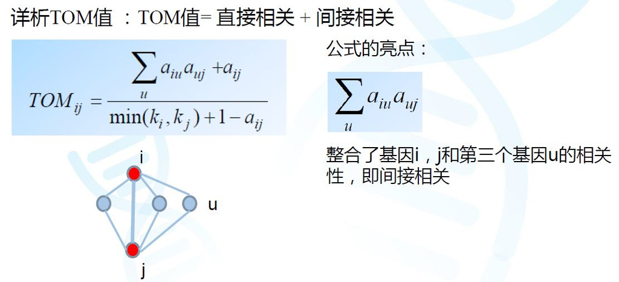

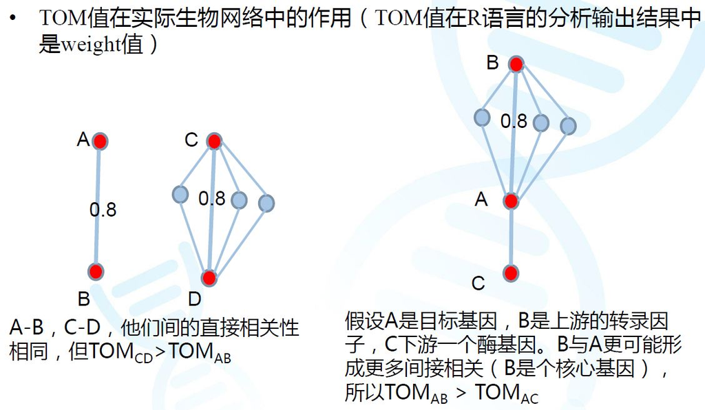

### Step4: 识别基因模块

为方便module identification，还需定义一个dissimilarity matrix

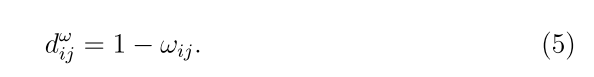

获得dissimilarity matrix 以后，剩下的工作就是聚类了，采用的是 hierarchical clustering 方法。

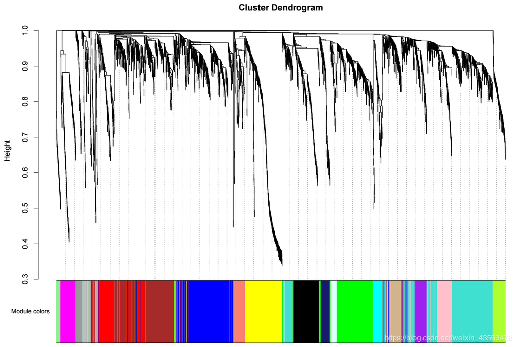

# 4. WGCNA生物学意义的挖掘

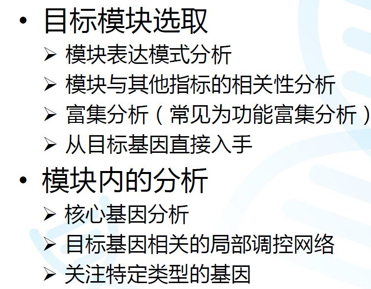